# Personal Sanitario No Enfermeria

Alicia Perdices Guerra

3 de mayo, 2021

#### **1.PROCESAMIENTO DE LOS DATOS.**

- En primer lugar leemos el fichero:

```r
sanitarios_ne<-read.csv("C:/temp/PersonalSanitario_No_enfermeria.csv",sep= ",")
```

- Realicemos una breve inspección de los datos

```r
str(sanitarios_ne)
```

```
## 'data.frame':    1600 obs. of  7 variables:
##  $ TIME              : int  2010 2010 2010 2010 2010 2010 2010 2010 2010 2010 ...
##  $ GEO               : Factor w/ 40 levels "Albania","Austria",..: 10 10 10 10 11 11 11 11 3 3 ...
##  $ UNIT              : Factor w/ 1 level "Number": 1 1 1 1 1 1 1 1 1 1 ...
##  $ WSTATUS           : Factor w/ 1 level "Practising": 1 1 1 1 1 1 1 1 1 1 ...
##  $ ISCO08            : Factor w/ 4 levels "Dentists","Medical doctors",..: 2 1 3 4 2 1 3 4 2 1 ...
##  $ Value             : Factor w/ 733 levels ":","1 102.00",..: 1 1 1 1 1 1 1 1 354 651 ...
##  $ Flag.and.Footnotes: Factor w/ 6 levels "","b","be","e",..: 1 1 1 1 1 1 1 1 1 1 ...
```

```r
colnames(sanitarios_ne) #Nombre de las variables
```

```
## [1] "TIME"               "GEO"                "UNIT"
## [4] "WSTATUS"            "ISCO08"             "Value"
## [7] "Flag.and.Footnotes"
```

```r
nrow(sanitarios_ne) #Número de registros
```

```
## [1] 1600
```

```r
ncol(sanitarios_ne) #Número de variables
```

```
## [1] 7
```

*Observamos las siguientes variables:

- **TIME**: variable cuantitativa. Indica el año en el que se ha realizado la medida, en este caso el valor de la variable “Value”. Se ha cargado bien como número entero.
- **GEO**: variable cualitativa. Indica el país o región en el que se ha realizado la medida.Se ha cargado bien como factor.
- **UNIT**: variable cualitativa. Indica la medida de la variable valor.Se ha cargado bien como factor.
- **WSTATUS**: variable cualitativa. Indica el estatus laboral del personal sanitario (no enfermería)
- **ISCO08**: Variable cualitativa. Indica si la variable “Value” se refiere a Médicos, Dentistas, Fisioterapeutas o Farmacéuticos.
- **Value**: Variable cuantitativa. Indica el número de profesionales de profesionales sanitarios por países.
- **Fal.and.footnotes**. Notas sobre etiquetas. Eliminamos esta columna.

*Años de las mediciones:

```r
unique(sanitarios_ne$TIME)
```

```
##  [1] 2010 2011 2012 2013 2014 2015 2016 2017 2018 2019
```

*Paises:

```r
unique(sanitarios_ne$GEO)
```

```
##  [1] European Union - 27 countries (from 2020)
##  [2] European Union - 28 countries (2013-2020)
##  [3] Belgium
##  [4] Bulgaria
##  [5] Czechia
##  [6] Denmark
##  [7] Germany (until 1990 former territory of the FRG)
##  [8] Estonia
##  [9] Ireland
## [10] Greece
## [11] Spain
## [12] France
## [13] France (metropolitan)
## [14] Croatia
## [15] Italy
```

[output cut: 26 more lines]

*Unidad de las mediciones:

```r
unique(sanitarios_ne$UNIT)
```

```
## [1] Number
## Levels: Number
```

*Variable que indica el estatus laboral del personal sanitario (no enfermería).

```r
unique(sanitarios_ne$WSTATUS)
```

```
## [1] Practising
## Levels: Practising
```

*Variable que indica cómo agrupamos el personal de sanitario para las mediciones.

```r
unique(sanitarios_ne$ISCO08)
```

```
## [1] Medical doctors  Dentists         Pharmacists      Physiotherapists
## Levels: Dentists Medical doctors Pharmacists Physiotherapists
```

- Eliminamos la columna Fal.and.footnotes.

```r
sanitarios_ne<-sanitarios_ne[,-7]
```

- Tendríamos que convertir la columna Value a numérico porque se ha cargado como factor y es erróneo. El resto de variables tienen el tipo correcto.

```r
sanitarios_ne$Value<-as.character(sanitarios_ne$Value)
sanitarios_ne$Value<-(gsub(',','.',sanitarios_ne$Value) )
sanitarios_ne$Value<-(gsub(' ','',sanitarios_ne$Value) )
sanitarios_ne$Value<-as.numeric(sanitarios_ne$Value)
```

- Comprobamos que valores tenemos en la columna **Value**:

```r
table(sanitarios_ne$Value, useNA = "ifany")
```

```
##
##      8      9     10     12     15     16     20     23     24     44     46
##      1      1      1      1      2      1      1      1      1      1      1
##     48     50     51     52    104    111    116    119    120    124    135
##      3      1      3      1      1      1      1      1      2      1      1
##    138    144    149    153    155    157    160    166    171    181    182
##      1      1      1      2      1      1      1      1      1      1      1
##    184    186    187    188    190    195    197    201    206    214    223
##      1      1      1      1      2      1      1      1      1      1      1
##    232    270    272    274    278    279    283    285    289    299    301
##      1      1      1      1      2      1      1      1      1      1      1
##    335    374    380    382    397    406    416    422    436    441    454
##      1      2      1      2      1      1      1      1      1      1      1
##    460    469    476    493    506    550    558    581    605    624    750
##      1      1      1      1      1      1      1      1      2      1      1
```

[output cut: 120 more lines]

- Observamos que tenemos **847 valores perdidos**.Guardamos en la variable **idx** los índices de los registros con valores **NA** de la variable **Value**.

```r
idx<-which(is.na(sanitarios_ne$Value))
length(idx)
```

```
## [1] 847
```

- Grafiquemos la información que contiene la variable **Value**

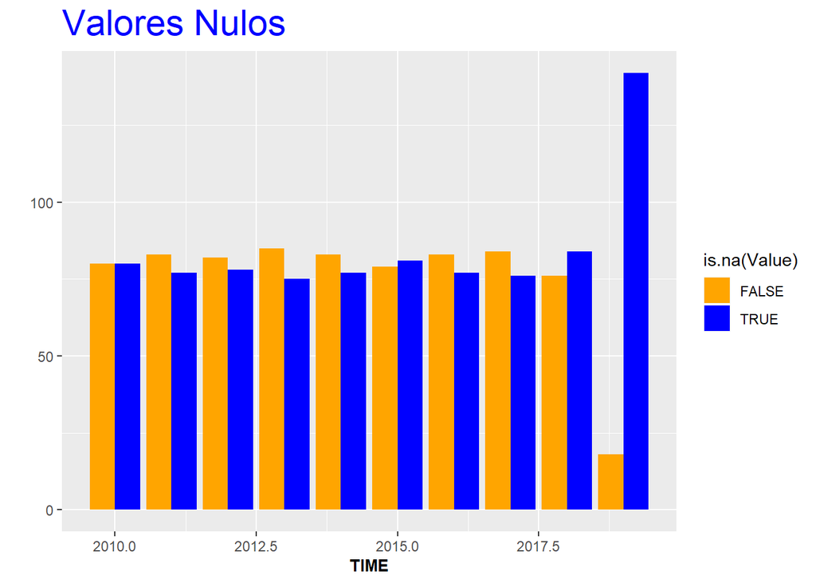

```r
library(ggplot2)
library(scales)
g = ggplot(sanitarios_ne, aes(TIME, fill=is.na(Value)) ) +
labs(title = "Valores Nulos")+ylab("") +
theme(plot.title = element_text(size = rel(2), colour = "blue"))

g+geom_bar(position="dodge") + scale_fill_manual(values = alpha(c("orange", "blue"), 1)) +
theme(axis.title.x = element_text(face="bold", size=10))
```

- En caso de detectar algún valor anómalo (en nuestro caso los NAS) en las variables tendríamos que realizar una imputación de esos valores o bien sustituyéndolos por la media o usando el algoritmo KNN ( k-Nearest Neighbour) con los 3 vecinos más cercanos usando la distancia que consideremos, en este caso usaremos Gower(Mediana), por ser una medida más robusa frente a extremos.

```r
library(VIM)
output<-kNN(sanitarios_ne, variable=c("Value"),k=3)
sanitarios_ne<-output
```

- Comprobamos que no tenemos valores nulos después de la imputación

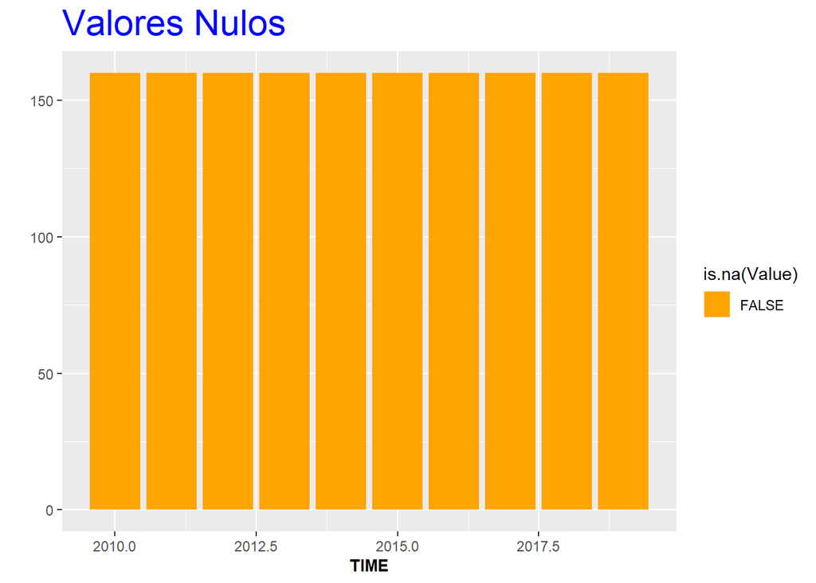

```r
g = ggplot(sanitarios_ne, aes(TIME, fill=is.na(Value)) ) +
labs(title = "Valores Nulos")+ylab("") +
theme(plot.title = element_text(size = rel(2), colour = "blue"))

g+geom_bar(position="dodge") + scale_fill_manual(values = alpha(c("orange", "blue"), 1)) +
theme(axis.title.x = element_text(face="bold", size=10))
```

- Con el siguiente gráfico, observaremos que la variable **Value** tiene outliers o valores extremos

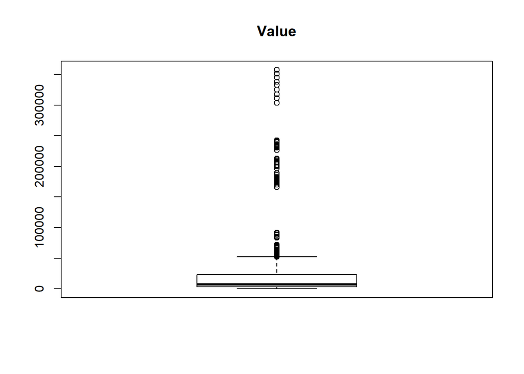

```r
boxplot(sanitarios_ne$Value, main="Value")
```

- Por otro lado, revisamos para el resto de columnas si tenemos valores NA.(desconocidos o perdidos)

```r
table(sanitarios_ne$TIME, useNA = "ifany")
```

```
##
## 2010 2011 2012 2013 2014 2015 2016 2017 2018 2019
##  160  160  160  160  160  160  160  160  160  160
```

```r
table(sanitarios_ne$GEO, useNA = "ifany")
```

```
##
##                                          Albania
##                                               40
##                                          Austria
##                                               40
##                                          Belgium
##                                               40
##                                         Bulgaria
##                                               40
##                                          Croatia
##                                               40
##                                           Cyprus
##                                               40
##                                          Czechia
##                                               40
##                                          Denmark
##                                               40
##                                          Estonia
##                                               40
##        European Union - 27 countries (from 2020)
##                                               40
##        European Union - 28 countries (2013-2020)
##                                               40
##                                          Finland
##                                               40
##                                           France
##                                               40
##                            France (metropolitan)
##                                               40
## Germany (until 1990 former territory of the FRG)
##                                               40
##                                           Greece
##                                               40
##                                          Hungary
##                                               40
##                                          Iceland
##                                               40
##                                          Ireland
##                                               40
##                                            Italy
```

[output cut: 26 more lines]

```
##                                               40
##                                         Slovakia
##                                               40
##                                         Slovenia
##                                               40
##                                            Spain
##                                               40
##                                           Sweden
##                                               40
##                                      Switzerland
##                                               40
##                                           Turkey
##                                               40
##                                   United Kingdom
##                                               40
```

```r
table(sanitarios_ne$UNIT, useNA = "ifany")
```

```
##
## Number
##   1600
```

```r
table(sanitarios_ne$WSTATUS, useNA = "ifany")
```

```
##
## Practising
##       1600
```

```r
table(sanitarios_ne$ISCO08, useNA = "ifany")
```

```
##
##         Dentists  Medical doctors      Pharmacists Physiotherapists
##              400              400              400              400
```

Observamos que no existen ahora valores perdidos después de la imputación.La suma de las cantidades de cada variable, suman el total.

- Finalmente, creamos un fichero con toda la información corregida.

```r
write.csv(sanitarios_ne, file="PersonalSanitario_No_enfermeria_clean.csv", row.names = FALSE)
```